# BCB420 Assignment 1

Kevin Zhu

## Objective of Assignment 1

The objective of this assignment is to produce a clean, normalized dataset that will be used for the following tasks in this course.

## Dataset Overview

γ-Secretase is a protease known to cleave the CTFs of amyloid-beta precursor protein (APP) at its gamma site. It is also known to cleave other substrates, and has been associated pathways governing cell differentiation. However, we still do not have a full understanding of what γ-Secretase does to non-proliferating cells (such as neurons).

Dysfunction of lipid metabolism neurons has been linked with Alzheimer’s Disease. In mouse embryonic fibroblasts (MEFs), γ-secretase inhibition lowered cellular cholesterol ester levels and reduced endocytosis of the low-density lipoprotein receptor (LDLR). However, No studies were carried out in human neurons, whose cholesterol metabolism is uniquely different from that of glia or peripheral cells.

The authors conducted RNA-seq experiments six biological replicates of induced human neuron cells. There were three treatment protocols: Control, DAPT, and LY411575. Specifically, DAPT and LY411575 treatments pharmaceutically induced chronic inhibition of γ-secretase. The associated GEO ID for this dataset is **GSE206102**.

## Installing dependencies and dowloading the packages

These dependencies has are already included with the command in the docker file

```r
if (!requireNamespace("BiocManager", quietly = TRUE)){
  install.packages("BiocManager")}

if (!requireNamespace("GEOmetadb", quietly = TRUE)){
  BiocManager::install("GEOmetadb")}

if (!requireNamespace("GEOmetadb", quietly = TRUE)){
  install.packages("knitr")}

if (!requireNamespace("edgeR", quietly = TRUE)){
  BiocManager::install("edgeR")}

if (!requireNamespace("biomaRt", quietly = TRUE)){
  BiocManager::install("biomaRt")}

if (!requireNamespace("DBI", quietly = TRUE)){
  install.packages("DBI")}

if (!requireNamespace("GEOquery", quietly = TRUE)){
  BiocManager::install("GEOquery")}

library(GEOquery)
library(knitr)
library(edgeR)
library(biomaRt)
library(dplyr)
library(purrr)
```

## Step 1: Loading the Expression Dataset

This step retrieves the gene expression data from the GEO, using the accession number **GSE206102**. Note that the supplemental data is compressed, and thus needs to be untarred to be accessible for later use.

### Introduction of Dataset

```r
dataset_geo_id <- 'GSE206102'

# downloading GEO dataset
gse <- getGEO(dataset_geo_id ,GSEMatrix = FALSE)

# Information about Platform
current_gpl <- names(GPLList(gse))[1]
current_gpl_info <- Meta(getGEO(current_gpl))

list_of_samples <- gse@gsms

# getting the sample descriptions
samples_type <- do.call(rbind, lapply(list_of_samples,
                                      FUN=function(x){
                                        c(x@header$title,
                                          x@header$characteristics_ch1)
                                        }
                                      )
                        )

colnames(samples_type) <- c("title",
                            "tissue",
                            "cell line",
                            "cell type",
                            "genotype",
                            "treatment")

samples_type[,'tissue'] <- gsub(samples_type[,'tissue'],
                                pattern = "tissue: ", replacement = "")
samples_type[,'cell line'] <- gsub(samples_type[,'cell line'],
                                   pattern = "cell line: ", replacement = "")
samples_type[,'cell type'] <- gsub(samples_type[,'cell type'],
                                   pattern = "cell type: ", replacement = "")
samples_type[,'genotype'] <- gsub(samples_type[,'genotype'],
                                   pattern = "genotype: ", replacement = "")
samples_type[,'treatment'] <- gsub(samples_type[,'treatment'],
                                   pattern = "treatment: ", replacement = "")

kable(samples_type[1:6,], format = "html")
```

|  | title | tissue | cell line | cell type | genotype | treatment |
| --- | --- | --- | --- | --- | --- | --- |
| GSM6241696 | Replicate1_CtrlV | Co-cultures of human induced neurons grown on mouse glia feeder layer | Human Induced Neurons from H1 ESC (WA01) | Human induced neurons, day 40 / mouse primary glia | Wild-type human induced neurons / CD1 mouse glia | Vehicle (0.5% DMSO), day in vitro 10-40 |
| GSM6241697 | Replicate1_DAPT | Co-cultures of human induced neurons grown on mouse glia feeder layer | Human Induced Neurons from H1 ESC (WA01) | Human induced neurons, day 40 / mouse primary glia | Wild-type human induced neurons / CD1 mouse glia | DAPT (40 uM), day in vitro 10-40 |
| GSM6241698 | Replicate1_LY411575 | Co-cultures of human induced neurons grown on mouse glia feeder layer | Human Induced Neurons from H1 ESC (WA01) | Human induced neurons, day 40 / mouse primary glia | Wild-type human induced neurons / CD1 mouse glia | LY411575 (2.5 uM), day in vitro 10-40 |
| GSM6241699 | Replicate2_CtrlV | Co-cultures of human induced neurons grown on mouse glia feeder layer | Human Induced Neurons from H1 ESC (WA01) | Human induced neurons, day 40 / mouse primary glia | Wild-type human induced neurons / CD1 mouse glia | Vehicle (0.5% DMSO), day in vitro 10-40 |
| GSM6241700 | Replicate2_DAPT | Co-cultures of human induced neurons grown on mouse glia feeder layer | Human Induced Neurons from H1 ESC (WA01) | Human induced neurons, day 40 / mouse primary glia | Wild-type human induced neurons / CD1 mouse glia | DAPT (40 uM), day in vitro 10-40 |
| GSM6241701 | Replicate2_LY411575 | Co-cultures of human induced neurons grown on mouse glia feeder layer | Human Induced Neurons from H1 ESC (WA01) | Human induced neurons, day 40 / mouse primary glia | Wild-type human induced neurons / CD1 mouse glia | LY411575 (2.5 uM), day in vitro 10-40 |

**GEO ID:** GSE206102

**Dataset Name:** Neuronal γ-secretase regulates lipid metabolism, linking cholesterol to synaptic dysfunction in Alzheimer’s disease

**Platform Title:** Illumina NovaSeq 6000 (Homo sapiens; Mus musculus)

**Technology:** high-throughput sequencing

**Submission Date:** Sep 04 2018

**Last Update Date:** Sep 04 2018

**Organism:** Homo sapiens, Mus musculus

### Downloading the Dataset

```r
# get the expression data
# TODO: check if supp file exists first before download
supp_files <- getGEOSuppFiles(dataset_geo_id, fetch_files = FALSE)
tar_sup_filename = supp_files$fname[1]

# untar files
download_dir <- file.path(getwd())
untar(tarfile = file.path(download_dir,dataset_geo_id,tar_sup_filename),
      exdir = file.path(download_dir,dataset_geo_id))
```

Now that the data has been uncompressed, we can begin reading and combining all the files.

```r
# Function to extract information from the filename
extract_info <- function(file) {
  parts <- strsplit(basename(file), "_")[[1]]
  data_id <- parts[1]
  sample_name <- toString(
    samples_type[, "title"][grep(data_id, rownames(samples_type))]
    )
  sample_name <- gsub(sample_name, pattern = "Replicate", replacement = "rep")
  return(sample_name)
  }

# get all the untarred files
file_list <- list.files(
  path = file.path(download_dir, dataset_geo_id),
  pattern = "\\.hs.tsv.gz$",
  full.names = TRUE
)

# load list of dataframes
data_list <- lapply(file_list, function(file) {
  df <- read.table(file, header = TRUE)
  df <- df[c("target_id", "est_counts")]

  counts_col <- extract_info(file)

  # replace 'est_counts' with a more readable name
  colnames(df)[colnames(df) == "est_counts"] <- counts_col
  return(df)
})

# combine list of dataframes using the appropriate ID
combined_table <- data_list %>% reduce(left_join, by = "target_id")

head(combined_table)
```

|  | target_id | rep1_CtrlV | rep1_DAPT | rep1_LY411575 | rep2_CtrlV | rep2_DAPT | rep2_LY411575 | rep3_CtrlV | rep3_DAPT | rep3_LY411575 | rep4_CtrlV | rep4_DAPT | rep4_LY411575 | rep5_CtrlV | rep5_DAPT | rep5_LY411575 | rep6_CtrlV | rep6_DAPT | rep6_LY411575 |
| --- | --- | --- | --- | --- | --- | --- | --- | --- | --- | --- | --- | --- | --- | --- | --- | --- | --- | --- | --- |
| 1 | ENST00000619216 | 2.7500 | 2.0000 | 2.5000 | 4.25000 | 1.75000 | 1.75 | 3.7500 | 3.00000 | 3.25000 | 1.50000 | 1.50000 | 1.0000 | 3.50000 | 1.75000e+00 | 2.750 | 2.250000 | 2.2500 | 2.2500 |
| 2 | ENST00000473358 | 15.4559 | 11.6043 | 43.4741 | 23.77240 | 6.76259 | 19.45 | 22.2488 | 6.61366 | 31.38130 | 7.60048 | 3.57007 | 21.6977 | 9.47226 | 1.00318e+01 | 18.788 | 0.000000 | 14.4737 | 10.6848 |
| 3 | ENST00000469289 | 0.0000 | 0.0000 | 0.0000 | 1.49996 | 0.00000 | 0.00 | 0.0000 | 0.00000 | 1.30403 | 0.00000 | 2.71681 | 0.0000 | 0.00000 | 0.00000e+00 | 0.000 | 1.250510 | 0.0000 | 0.0000 |
| 4 | ENST00000607096 | 0.0000 | 0.0000 | 0.0000 | 0.00000 | 0.00000 | 0.00 | 0.0000 | 0.00000 | 0.00000 | 0.00000 | 0.00000 | 0.0000 | 0.00000 | 0.00000e+00 | 0.000 | 0.000000 | 0.0000 | 0.0000 |
| 5 | ENST00000417324 | 0.0000 | 0.0000 | 0.0000 | 0.00000 | 0.00000 | 0.00 | 0.0000 | 0.00000 | 0.00000 | 0.00000 | 0.00000 | 0.0000 | 0.00000 | 0.00000e+00 | 0.000 | 0.099592 | 0.0000 | 0.0000 |
| 6 | ENST00000641515 | 3.0000 | 0.0000 | 0.0000 | 0.00000 | 0.00000 | 0.00 | 0.0000 | 1.00000 | 0.00000 | 0.00000 | 0.00000 | 0.0000 | 0.00000 | 4.47401e-08 | 0.000 | 0.000000 | 0.0000 | 0.0000 |

```r
dim(combined_table)
```

```
## [1] 90201    19
```

## Step 2: Cleaning the Data

This step is necessary as the data table we have compiled contains counts at the transcript level. We must first map this data to the proper HUGO symbols before proceeding to any other steps. We can use `biomaRt` to accomplish this.

### Converting Dataset from Transcript to Gene Level

.

```r
ensembl <- useMart("ensembl", dataset = "hsapiens_gene_ensembl")

ensembl_transcript_ids <- dplyr::pull(combined_table, target_id)

# this step might take some time as it needs to query the database
transcript_info <- getBM(attributes = c("ensembl_transcript_id",
                                        "external_gene_name"),
                         filters = "ensembl_transcript_id",
                         values = ensembl_transcript_ids,
                         mart = ensembl)

hgnc_combined_table <- merge(combined_table, transcript_info,
                          by.x = "target_id",
                          by.y = "ensembl_transcript_id",
                          all.x = TRUE) %>% relocate(target_id,
                                                     external_gene_name)

head(hgnc_combined_table)
```

|  | target_id | external_gene_name | rep1_CtrlV | rep1_DAPT | rep1_LY411575 | rep2_CtrlV | rep2_DAPT | rep2_LY411575 | rep3_CtrlV | rep3_DAPT | rep3_LY411575 | rep4_CtrlV | rep4_DAPT | rep4_LY411575 | rep5_CtrlV | rep5_DAPT | rep5_LY411575 | rep6_CtrlV | rep6_DAPT | rep6_LY411575 |
| --- | --- | --- | --- | --- | --- | --- | --- | --- | --- | --- | --- | --- | --- | --- | --- | --- | --- | --- | --- | --- |
| 1 | ENST00000000233 | ARF5 | 2734.000 | 2372.0000 | 3015.8200 | 2342.760 | 2011.7100 | 2689.000 | 2248.0000 | 2330.000 | 2300.0000 | 1342.0000 | 2071.7700 | 1603.0000 | 1403.00000 | 1485.750 | 1339.000 | 1392.0000 | 1349.770 | 1435.000 |
| 2 | ENST00000000412 | M6PR | 885.566 | 933.9460 | 1105.2900 | 873.244 | 678.3160 | 972.755 | 862.8320 | 884.094 | 961.3240 | 579.0550 | 846.8300 | 652.9250 | 618.12200 | 613.110 | 523.136 | 592.6490 | 550.789 | 615.443 |
| 3 | ENST00000000442 | ESRRA | 84.803 | 77.7512 | 33.4483 | 111.663 | 85.8932 | 112.695 | 33.7991 | 106.971 | 88.0364 | 28.2364 | 62.1185 | 68.2176 | 5.73036 | 63.598 | 56.882 | 46.1058 | 53.019 | 47.168 |
| 4 | ENST00000001008 | FKBP4 | 2831.260 | 2445.6100 | 3190.9600 | 2538.200 | 2141.4400 | 2714.260 | 2397.7900 | 2400.790 | 2412.6100 | 1598.8100 | 2392.6100 | 1749.7100 | 1678.00000 | 1698.740 | 1341.460 | 1684.2900 | 1648.000 | 1594.280 |
| 5 | ENST00000001146 | CYP26B1 | 645.747 | 589.7990 | 774.8050 | 740.496 | 656.6520 | 683.412 | 729.1160 | 799.756 | 837.4220 | 277.2660 | 424.2990 | 333.0740 | 255.96600 | 341.835 | 275.995 | 303.6160 | 416.597 | 303.308 |
| 6 | ENST00000002125 | NDUFAF7 | 205.221 | 202.6920 | 283.4140 | 214.450 | 167.1990 | 261.997 | 238.8490 | 236.763 | 245.6210 | 131.3200 | 217.7730 | 161.8160 | 159.25200 | 162.725 | 111.452 | 163.7660 | 152.295 | 153.237 |

```r
dim(hgnc_combined_table)
```

```
## [1] 90201    20
```

Unfortunately, there were transcripts in which `biomaRt` was unable to find the corresponding HUGO gene symbol. Looking through these missing transcripts, it seems like the majority of them are outdated and thus no longer in the current gene set.

```r
missing_values <- hgnc_combined_table[
  is.na(hgnc_combined_table$external_gene_name), ]$target_id

length(missing_values)
```

```
## [1] 3300
```

### Filtering the Data

Now that we have a table with the appropriate HUGO gene symbol for each transcript, we can begin actually filtering the data.

```r
# remove rows that do not have HUGO symbol
hgnc_combined_table <- hgnc_combined_table[
  !is.na(hgnc_combined_table$external_gene_name), ]

# counts are currently still on the transcript-level
hgnc_combined_table <- subset(hgnc_combined_table, select = -c(target_id))

# we are summing the transcript count values when they share the same gene ID
hgnc_combined_table <- hgnc_combined_table %>%
  group_by(external_gene_name) %>%
  summarise_all(sum)

dim(hgnc_combined_table)
```

```
## [1] 30895    19
```

Now that we have gene-level counts, we can start filtering out the low-count genes

```r
# there are 6 samples for each condition, removing low counts
min_samples <- 6
keep <- rowSums( edgeR::cpm(subset(hgnc_combined_table,
                                   select = -c(external_gene_name)))
                 > 1 ) >= min_samples
filtered_table <- hgnc_combined_table[keep, ]
dim(filtered_table)
```

```
## [1] 14380    19
```

## Step 3: Normalizing the Data

Now that we have cleaned our data, we can now proceed to the normalization step. Before this, we must look at how our data looks pre-normalized.

### Initial Plotting

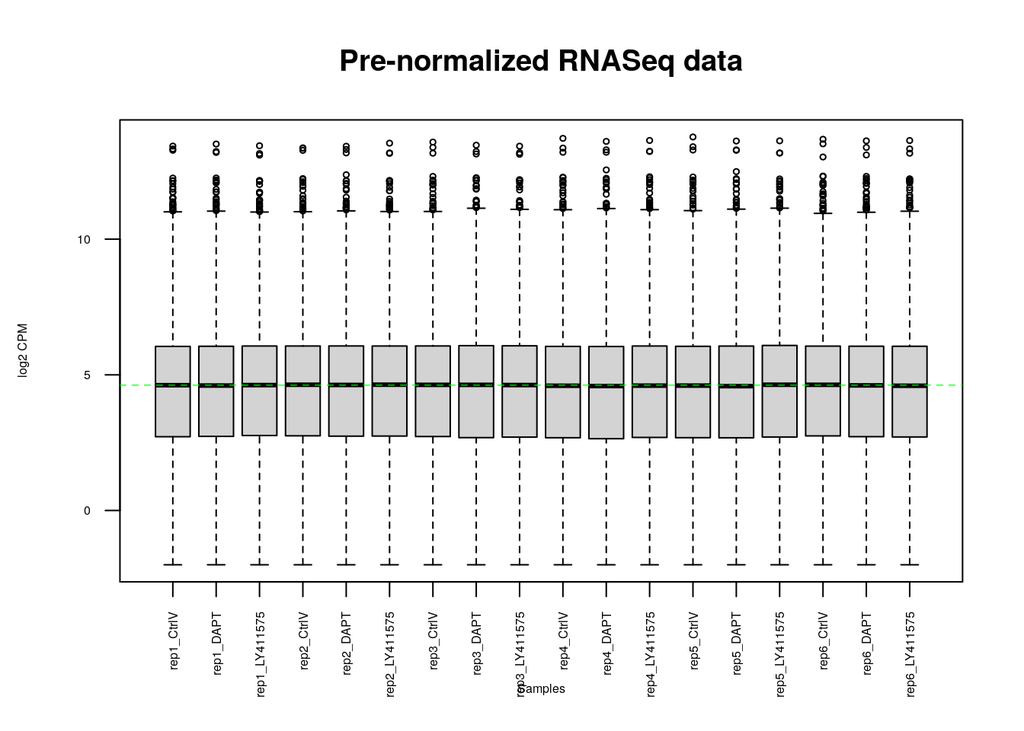

```r
# boxplot for pre-normalized dataset
# we do add a pseudocount of 0.25 to ensure negative log values do not explode
data2plot <- log2(cpm(subset(filtered_table, select =
                               -c(external_gene_name)))+0.25)

boxplot(data2plot,xlab = "Samples", ylab = "log2 CPM",
 las = 2, cex = 0.5, cex.lab = 0.5,
 cex.axis = 0.5, main = "Pre-normalized RNASeq data")

#draw the median on each box plot
abline(h = median(apply(data2plot, 2, median)),
 col = "green", lwd = 0.6, lty = "dashed")
```

The overall distributions between the samples look almost identical, with medians and quartiles at the same values. We will nevertheless still apply a normalization to see what it looks like. This is confirmed by the density plot, as shown below:

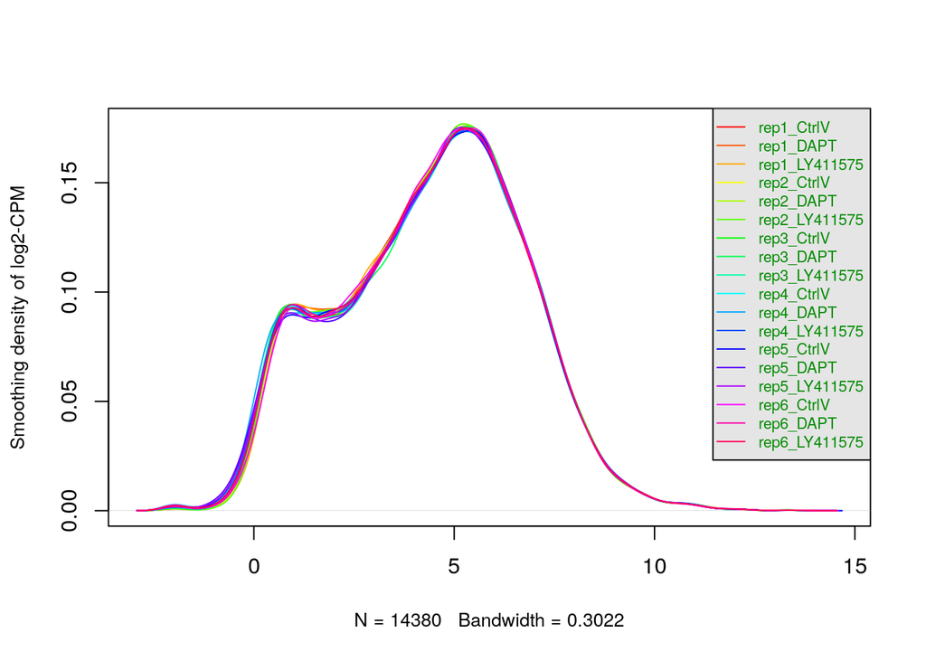

```r
counts_density <- apply(data2plot, 2, density)

# calculate the limits across all the samples
xlim <- 0
ylim <- 0
for (i in 1:length(counts_density)) {
  xlim <- range(c(xlim, counts_density[[i]]$x))
  ylim <- range(c(ylim, counts_density[[i]]$y))
}

cols <- rainbow(length(counts_density))
ltys <- rep(1, length(counts_density))

# plot the first density plot to initialize the plot
plot(counts_density[[1]], xlim=xlim, ylim=ylim, type="n",
     ylab="Smoothing density of log2-CPM",
     main="", cex.lab = 0.85)

# plot each line
for (i in 1:length(counts_density))
  lines(counts_density[[i]], col=cols[i], lty=ltys[i])

# create legend
legend("topright", colnames(data2plot),
       col=cols, lty=ltys, cex=0.7,
       border ="blue", text.col = "green4",
       merge = TRUE, bg = "gray90")
```

### Normalization using TMM

```r
filtered_data_matrix <- as.matrix(subset(filtered_table, select =
                                     -c(external_gene_name)))
# let rownames be the HGNC symbols
rownames(filtered_data_matrix) <- filtered_table$external_gene_name
groups <- colnames(subset(filtered_table, select = -c(external_gene_name)))
# d = DGEList(counts=filtered_data_matrix, group=groups)
d = DGEList(counts=filtered_table, group=groups)
```

```
## Setting first column of `counts` as gene annotation.
```

```r
# normalization
d = calcNormFactors(d)
normalized_counts <- cpm(d)
rownames(normalized_counts) <- filtered_table$external_gene_name
nrow(normalized_counts)
```

```
## [1] 14380
```

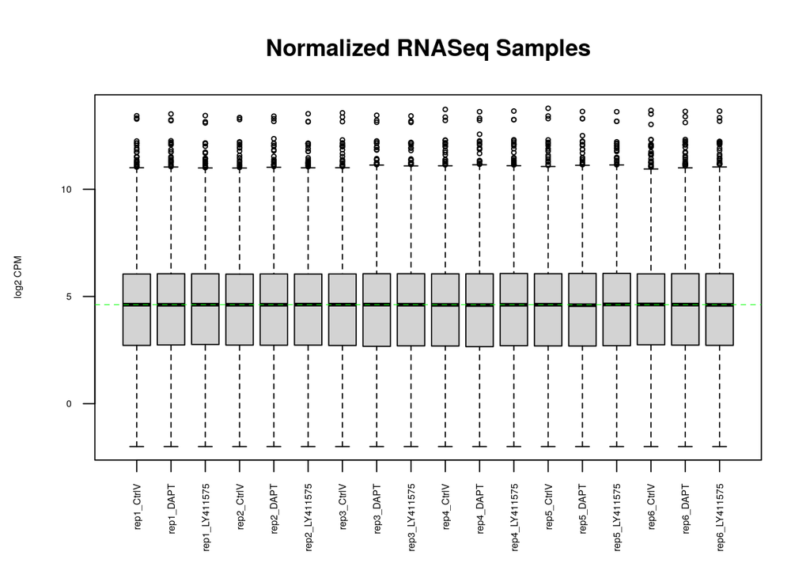

```r
# we do add a pseudocount of 0.25 to ensure negative log values do not explode
data2plot_after <- log2(normalized_counts + 0.25)
boxplot(data2plot_after, ylab = "log2 CPM",
 las = 2, cex = 0.5, cex.lab = 0.5,
 cex.axis = 0.5, main = "Normalized RNASeq Samples")
#draw the median on each box plot
abline(h = median(apply(data2plot_after, 2, median)),
 col = "green", lwd = 0.6, lty = "dashed")
```

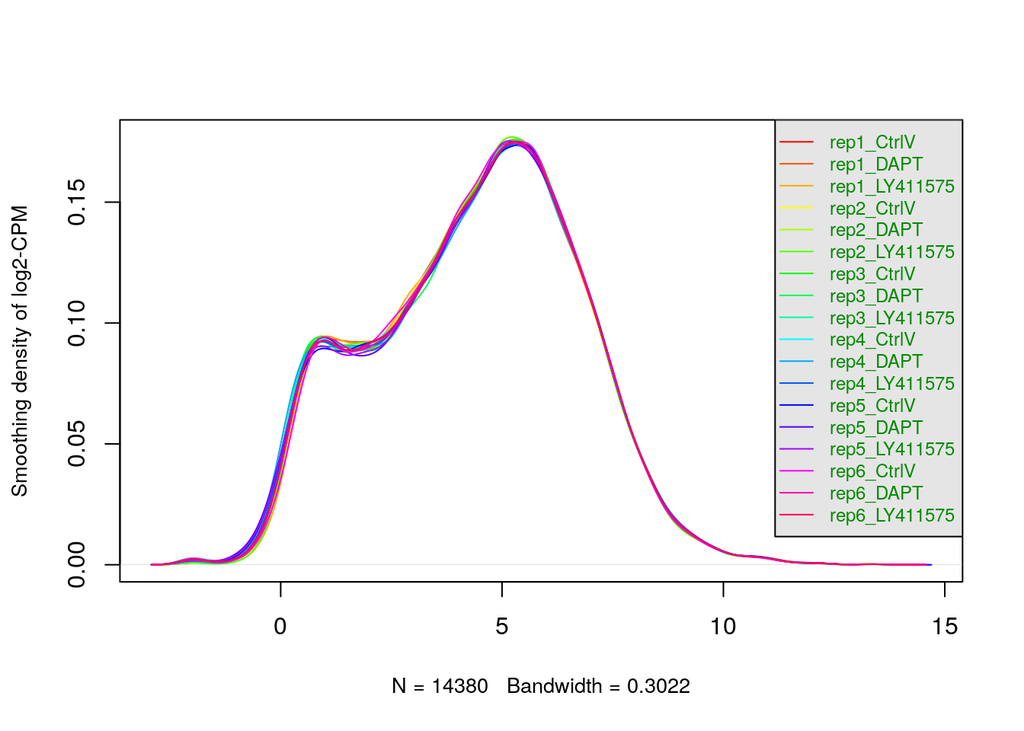

```r
counts_density <- apply(data2plot_after, 2, density)

# Calculate the limits across all the samples
xlim <- 0
ylim <- 0
for (i in 1:length(counts_density)) {
  xlim <- range(c(xlim, counts_density[[i]]$x))
  ylim <- range(c(ylim, counts_density[[i]]$y))
}

cols <- rainbow(length(counts_density))
ltys <- rep(1, length(counts_density))

# Plot the first density plot to initialize the plot
plot(counts_density[[1]], xlim=xlim, ylim=ylim, type="n",
     ylab="Smoothing density of log2-CPM", main="", cex.lab = 0.85)

# Plot each line
for (i in 1:length(counts_density))
  lines(counts_density[[i]], col=cols[i], lty=ltys[i])

# Create legend
legend("topright", colnames(data2plot),
       col=cols, lty=ltys, cex=0.75,
       border ="blue", text.col = "green4",
       merge = TRUE, bg = "gray90")
```

We can see that these results are essentially identical to the plot we made earlier. This likely means that the data had already been normalized. It was good to check though.

## Step 4: Initial Analysis and Discussion

In this step, we can perform further analyses to see how the data is distributed, as well as how seeing how samples differ across treatments.

### MDS Plotting

We can visuzlize the sample separation using a multidimenstional scaling plot post normalization.

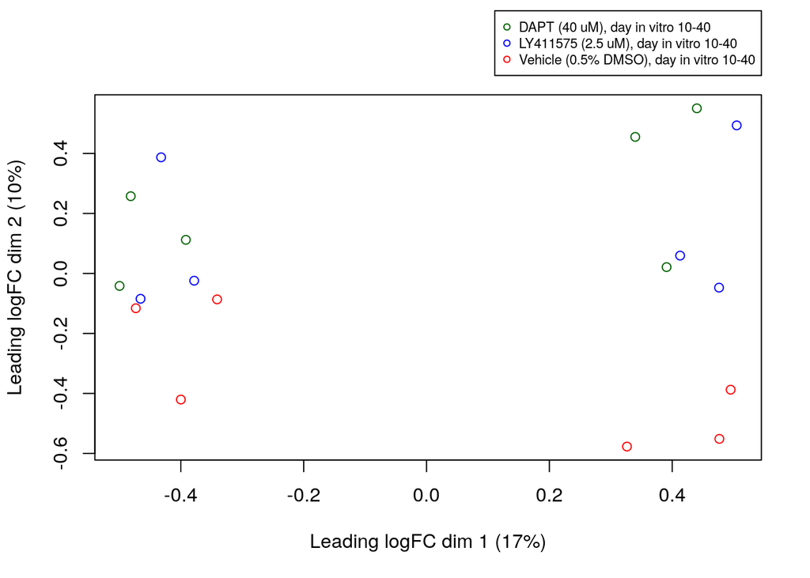

```r
# plotMDS(d, labels=groups,
#   col = c("darkgreen","blue", "red")[factor(samples_type[, "treatment"])]
# )

plotMDS(d, labels=NULL,pch=1,
  col = c("darkgreen","blue", "red")[factor(samples_type[, "treatment"])]
)
par(xpd = T)
legend("topright",
legend=levels(factor(samples_type[, "treatment"] )),
pch=c(1), col= c("darkgreen","blue", "red"),
cex = 0.7, inset=c(0,-0.23))
```

We can see from the MDS plot above that there does seem to be some separation between the control samples and the ones with the γ-secretase inhibitors.

```r
# model_design <- model.matrix(~samples_type[, "treatment"]+
#                                samples_type[, "cell line"])
# d <- estimateDisp(d, model_design)
# plotBCV(d, col.tagwise = "black", col.common = "red", )
```

### Writing Out the Data

```r
write.table(normalized_counts,
            file.path(
              getwd(),
              dataset_geo_id,
              paste(dataset_geo_id,
                    "normalized_filtered_RSEM_counts.txt",sep="_")
              ),
            quote = FALSE,sep="\t",row.names = TRUE)
```

### Questions and Answers

**Why is the dataset of interest to you?**  
Alzheimer’s disease (AD); it is the most common cause of dementia but there haven’t been any successful therapeutic interventions for this issue. More recently, there have been interesting observations regarding the relationship between dysfunction in lipid metabolism and neuroinflammation in AD. This dataset and its associate paper aims to elucidate this relationship by investigating the direct causal relationship between γ-secretase, cholesterol, and synapses.

**Were there expression values that were not unique for specific genes?**  
This dataset was originally published at the transcript level using ensembl transcript IDs. After mapping these transcripts to their corresponding HUGO symbols, there were many duplicates, as multiple transcripts can be mapped to the same gene. In order fix this issue, I simply summed over the counts of transcripts that mapped to the same gene.

**Were there expression values that couldn’t be mapped to HUGO symbols?**  
There were a few transcripts in the original dataset that likely had outdated ensembl IDs, as `biomaRt` was unable to locate their HUGO symbol. After the conversion step from transcript to gene-level expression, 3300 transcripts were omitted from the dataset.

**How did you handle replicates?**  
The dataset contained six biological replicates, each with three treatments. Thus, the final output data table has 18 columns (six biological replicates, each with three treatments). Note that when removing genes with low sample counts, I removed entire rows to keep the data well-organized.

**What is the final coverage of your dataset?**  
The final dataset coverage is 14380 genes. There are 18 columns (six biological replicates, each with three treatments).

## References

Davis, S. and Meltzer, P. S. GEOquery: a bridge between the Gene Expression Omnibus (GEO) and BioConductor. Bioinformatics, 2007, 14, 1846-1847

Essayan-Perez, Sofia, and Thomas C Südhof. “Neuronal γ-Secretase Regulates Lipid Metabolism, Linking Cholesterol to Synaptic Dysfunction in Alzheimer’s Disease.” Neuron, vol. 111, no. 20, 1 Oct. 2023, pp. 3176-3194.e7, https://doi.org/10.1016/j.neuron.2023.07.005.

Robinson MD, McCarthy DJ and Smyth GK (2010). edgeR: a Bioconductor package for differential expression analysis of digital gene expression data. Bioinformatics 26, 139-140

Mapping identifiers for the integration of genomic datasets with the R/Bioconductor package biomaRt. Steffen Durinck, Paul T. Spellman, Ewan Birney and Wolfgang Huber, Nature Protocols 4, 1184-1191 (2009).

Martin, Fergal J., et al. “Ensembl 2023.” Nucleic Acids Research, vol. 51, no. D1, 6 Jan. 2023, pp. D933–D941, pubmed.ncbi.nlm.nih.gov/36318249/, https://doi.org/10.1093/nar/gkac958.

Wickham H, Henry L (2023). *purrr: Functional Programming Tools*. R package version 1.0.2, https://github.com/tidyverse/purrr, https://purrr.tidyverse.org/.

Wickham H, François R, Henry L, Müller K, Vaughan D (2023). *dplyr: A Grammar of Data Manipulation*. R package version 1.1.4, https://CRAN.R-project.org/package=dplyr.

Yihui Xie (2015) Dynamic Documents with R and knitr. 2nd edition. Chapman and Hall/CRC. ISBN 978-1498716963